# Peer Assignment 1 - Reproducible Research

Kiichi Takeuchi

July 16, 2014

## Setup

First, setup your work directory path. For example, here is my path below. If you are using R Studio, you can also set it from Session > Set Working Directory > To Source File Location.

```r
setwd("~/work/r/class/RepData_PeerAssessment1")
```

Below is the list of required R packages for this analysis: * data.table * ggplot2

Download and extract Zip file if it was not extracted yet

```r
if (!file.exists("activity.zip")){
  download.file("https://d396qusza40orc.cloudfront.net/repdata%2Fdata%2Factivity.zip","activity.zip",method="curl")
}

if (!file.exists("activity.csv")){
  unzip("activity.zip")
}
```

## Loading Data

Next, load the data file

```r
library(data.table)
data<-fread("activity.csv")
```

## Calculate Steps per Day and Histogram

```r
library(ggplot2)
sum_by_date <- data[,list(total=sum(steps,na.rm=T)),by=date]
```

Draw histogram of Steps per Day

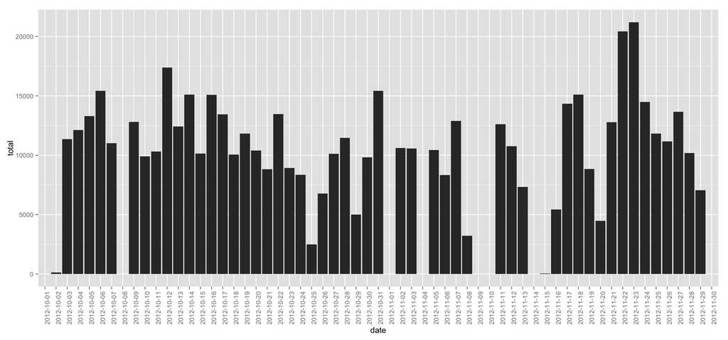

```r
ggplot(sum_by_date, aes(x=date, y=total)) + geom_bar(stat = "identity") + theme(axis.text.x = element_text(angle = 90,hjust = 1))# + coord_flip()# + scale_x_reverse()
```

## Mean and Median

```r
mean_val1<-mean(sum_by_date$total)
mean_val1
```

```
## [1] 9354
```

```r
median_val1<-median(sum_by_date$total)
median_val1
```

```
## [1] 10395
```

## The average daily activity pattern

Time Series Plot would be generated as below. The 5-minute interval and the average number of steps taken, averaged across all days.

```r
avg_interval <- data[,list(avg=mean(steps,na.rm=T)),by=interval]
head(avg_interval,5)
```

```
##    interval     avg
## 1:        0 1.71698
## 2:        5 0.33962
## 3:       10 0.13208
## 4:       15 0.15094
## 5:       20 0.07547
```

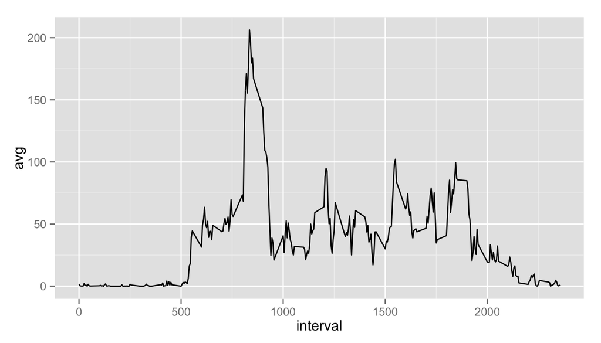

```r
ggplot(data=avg_interval,aes(x=interval,y=avg)) + geom_line()
```

The max average steps and which interval is it?

```r
avg_interval[avg==max(avg_interval$avg),]
```

```
##    interval   avg
## 1:      835 206.2
```

Total Number of NA (Missing Values)

```r
sum(is.na(data$steps))
```

```
## [1] 2304
```

## Imputing missing values

Here is the approach that I took to fill those missing values. I’ve used average value of each interval in order to replace NA in steps column. Before filling data, I merged original data table with average table by interval as the key. Make sure order by date and interval after the process.

```r
data_avg<-merge(data,avg_interval,by="interval")[order(date,interval)]
head(data_avg,5)
```

```
##    interval steps       date     avg
## 1:        0    NA 2012-10-01 1.71698
## 2:        5    NA 2012-10-01 0.33962
## 3:       10    NA 2012-10-01 0.13208
## 4:       15    NA 2012-10-01 0.15094
## 5:       20    NA 2012-10-01 0.07547
```

```r
data_f<-data # copy data first
data_f[is.na(data_f$steps),c('steps')]<-as.integer(data_avg[is.na(data_f$steps),avg])
head(data_f,5)
```

```
##    steps       date interval
## 1:     1 2012-10-01        0
## 2:     0 2012-10-01        5
## 3:     0 2012-10-01       10
## 4:     0 2012-10-01       15
## 5:     0 2012-10-01       20
```

```r
sum(is.na(data$steps))
```

```
## [1] 2304
```

Here is the same analysis that I did above but I use the new data without missing values: histogram, mean and median.

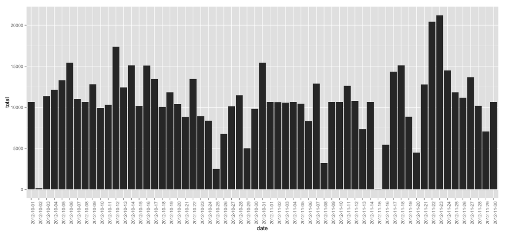

```r
sum_by_date_f <- data_f[,list(total=sum(steps,na.rm=T)),by=date]
ggplot(sum_by_date_f, aes(x=date, y=total)) + geom_bar(stat = "identity") + theme(axis.text.x = element_text(angle = 90,hjust = 1))# + coord_flip()# + scale_x_reverse()
```

```r
mean_val2<-mean(sum_by_date_f$total)
mean_val2
```

```
## [1] 10750
```

```r
median_val2<-median(sum_by_date_f$total)
median_val2
```

```
## [1] 10641
```

# Weekdays and Weekends

In this section, I will categorize date into two factors : weekday and weekend, and we explore the diffences.

```r
days<-weekdays(as.Date(data_f$date,'%Y-%m-%d'))
data_f[,c('day_in_week')]<-days
data_f[,c('day_type')]<-factor(days=='Saturday' | days=='Sunday', labels=c('weekday','weekend'))
head(data_f,5)
```

```
##    steps       date interval day_in_week day_type
## 1:     1 2012-10-01        0      Monday  weekday
## 2:     0 2012-10-01        5      Monday  weekday
## 3:     0 2012-10-01       10      Monday  weekday
## 4:     0 2012-10-01       15      Monday  weekday
## 5:     0 2012-10-01       20      Monday  weekday
```

Render weekend steps

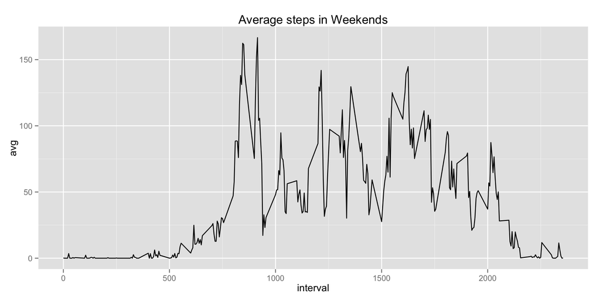

```r
avg_weekend <- data_f[day_type == 'weekend',list(avg=mean(steps,na.rm=T)),by=interval]
ggplot(data=avg_weekend,aes(x=interval,y=avg)) + geom_line() + ggtitle("Average steps in Weekends")
```

Render weekday steps

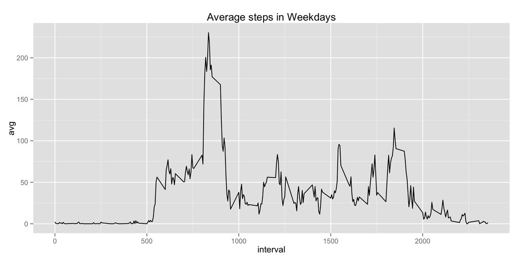

```r
avg_weekday <- data_f[day_type == 'weekday',list(avg=mean(steps,na.rm=T)),by=interval]
ggplot(data=avg_weekday,aes(x=interval,y=avg)) + geom_line() + ggtitle("Average steps in Weekdays")
```